# Module 13: Mapping with R

Brian P Steves

2024-11-18

```r
# hide warnings
knitr::opts_chunk$set(warning=FALSE, message=FALSE)
```

There are a lot of ways to create maps in R. In fact, there are many different packages to choose from when it comes to making maps. In this module, I will cover some of the basics with a few packages to give you an overview of the options.

There are also lots of tutorials online if you want more information.

- https://ggplot2.tidyverse.org/reference/coord_map.html
- http://cran.r-project.org/web/views/Spatial.html
- http://rpubs.com/alobo/getmapCRS
- https://r.geocompx.org/

## Large scale maps with polical boudaries (world, countries, counties)

Sometimes you want a very simple clean map with just a few polical boundries. This is particularly useful for maps on a large scale (the world, the state, the county) to show where your study site is, but it’s not so good if you want to show your particular sampling locations around a small pond.

### Simple maps using “maps” package

The simplist way to make a map is using the map() function in the “maps” package. This package comes with map data for the countries of the world, US states, US counties, and a select few other country maps.

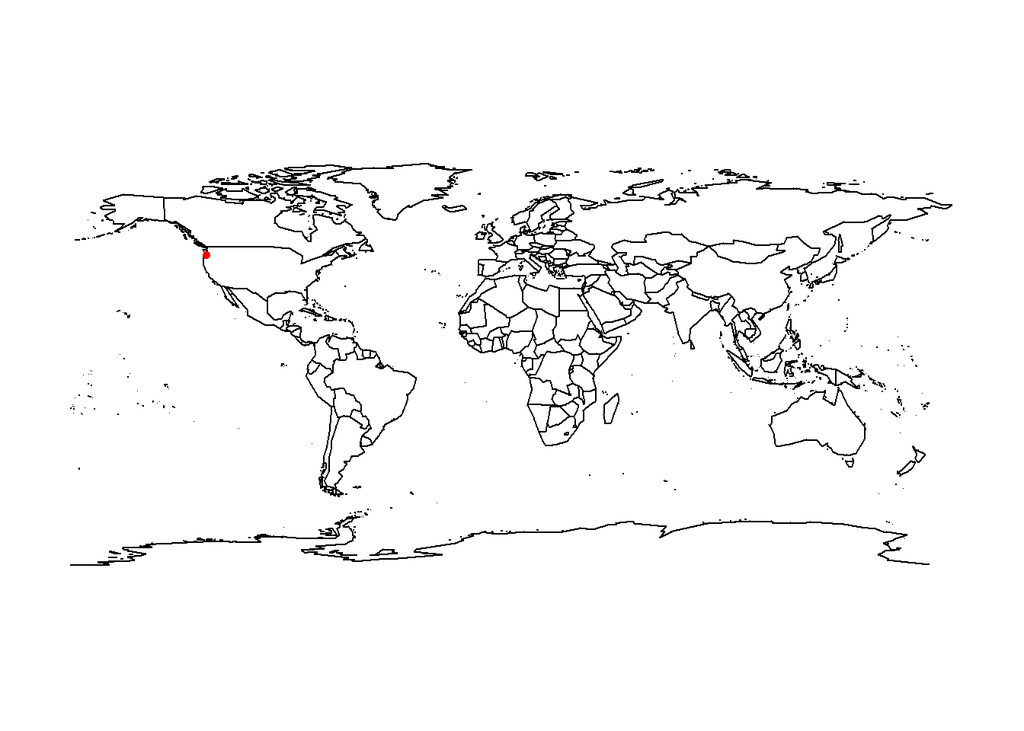

```r
library(maps)
# simple map of the world
map("world")

# add a point (roughly portland)
pdx_lat <- 45.52
pdx_lon <- -122.68
points(pdx_lon, pdx_lat, col="red", pch=20, cex=1)
```

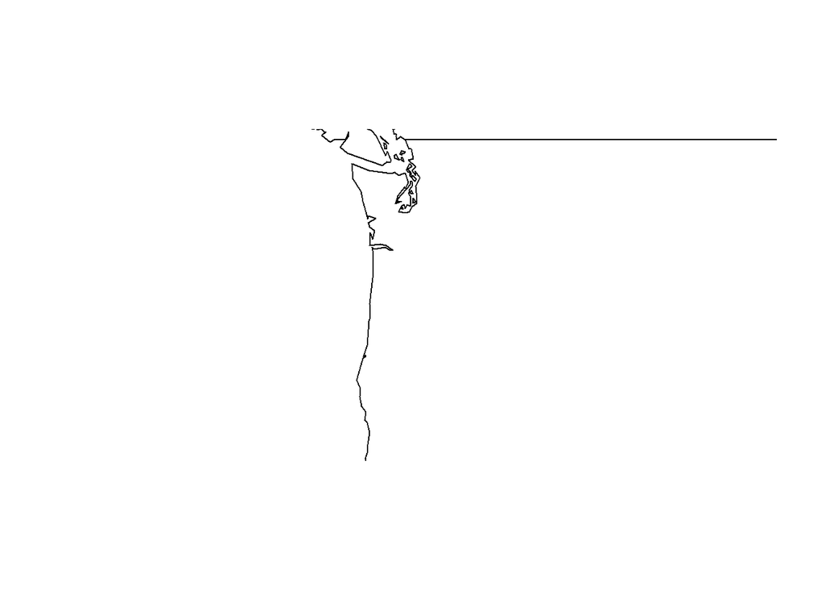

```r
# If you want, you can zoom into the map by altering the xlim and ylim.  Let's zooom in to the Pacific Northwest.
map("world", xlim=c(-130,-115), ylim=c(40,50))
```

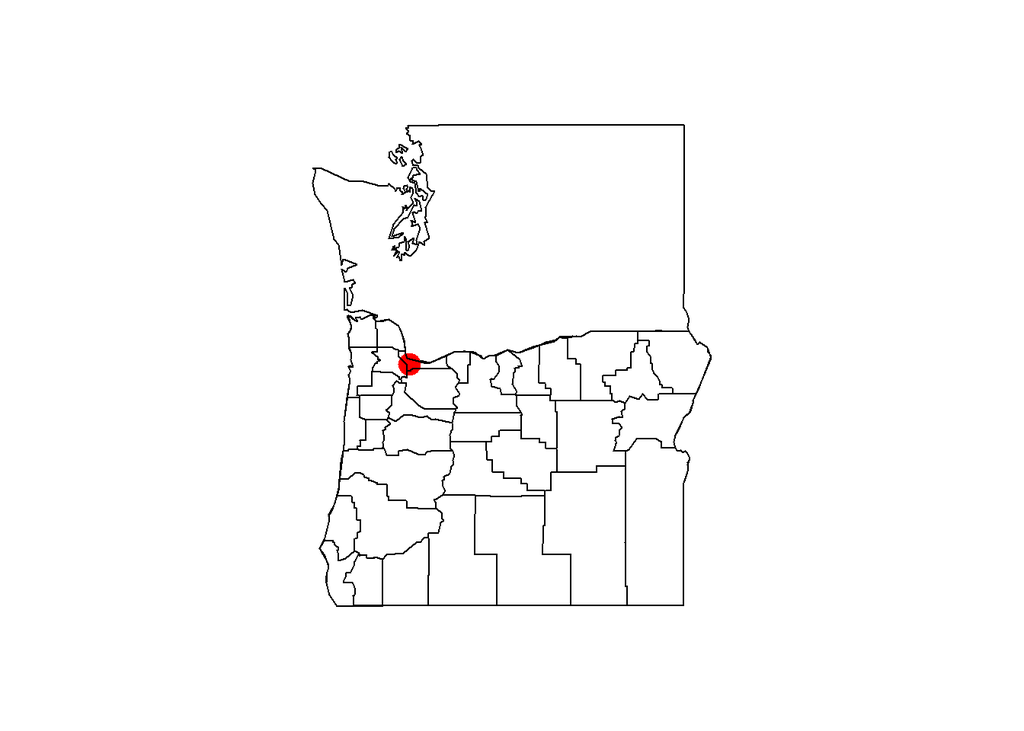

```r
# Yick, the resolution isn't so hot.  Let's try using the state level maps.
map("state", region=c("Washington", "Oregon"))

# Add a point for Portland.
points(pdx_lon, pdx_lat, col="red", pch=20, cex=3)

# Now let's add the counties to Oregon
map("county", "Oregon", add=T)
```

## Plotting Shapefiles

If you want to move beyond the limits of the maps packacke you’ll want to be able to plot shapefiles. If you are familiar with GIS you probably know what those are. If not, just think of them as vectorized map files.

### Plotting a shapefile using “terra” package

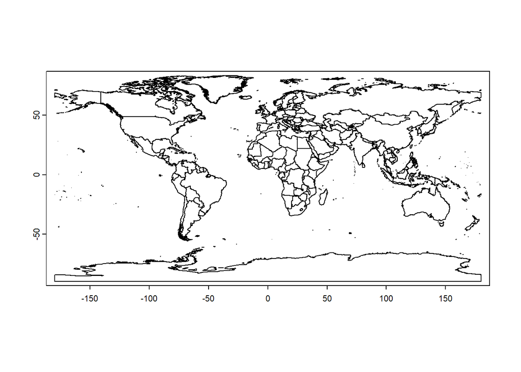

```r
library(terra)

shpfile <- "H:/Geoprocessing_Shapefiles/Countries.shp"
countries <- vect(shpfile)
plot(countries)
```

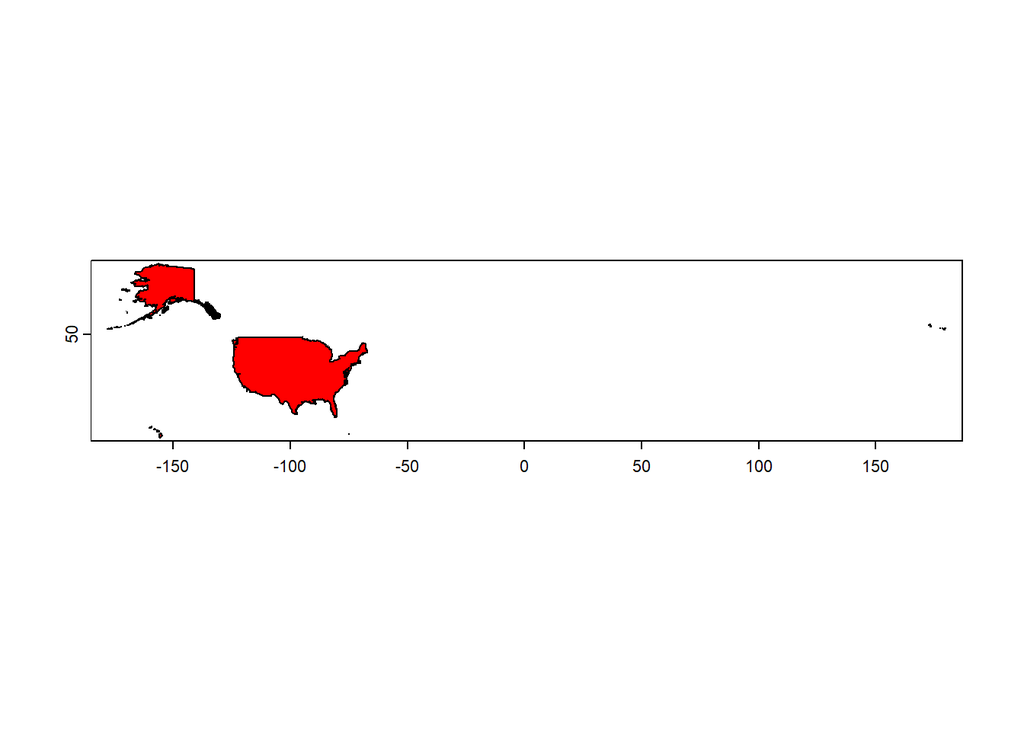

```r
USA <- vect(shpfile, query="SELECT OBJECTID_1, CNTRY_NAME FROM countries WHERE CNTRY_NAME = 'USA'")
plot(USA, col="red")
```

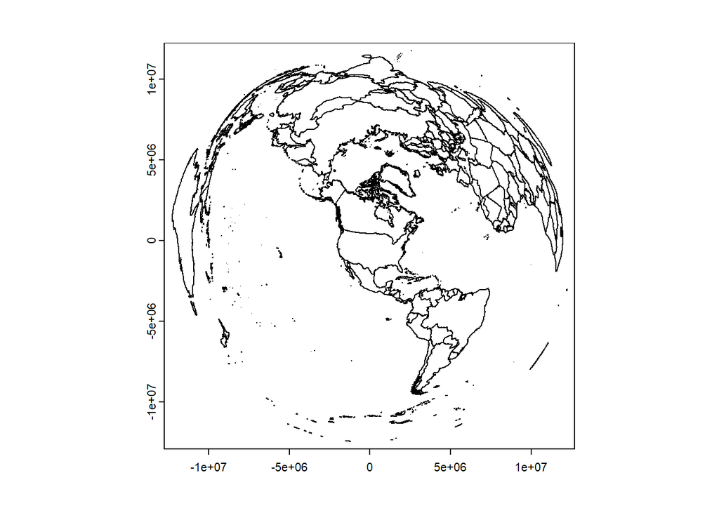

```r
# change the projection
countries <- project(countries, "+proj=laea +lat_0=45 +lon_0=-100")
plot(countries)
```

### Plotting a shapefile using the “sf” package

```r
library(sf)
countries_sf <- st_read("H:/Geoprocessing_Shapefiles/Countries.shp")
```

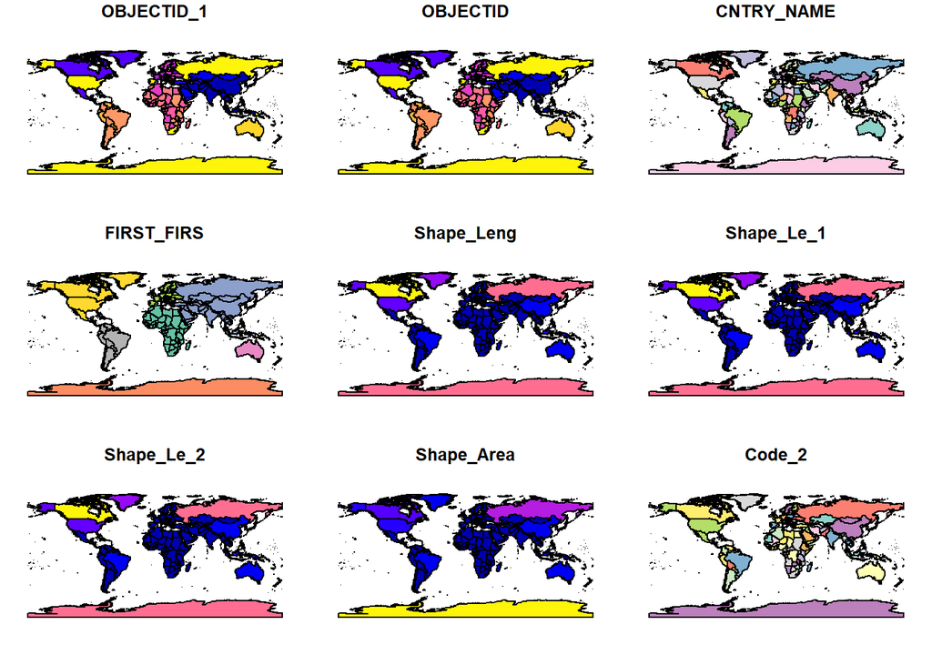

```r
plot(countries_sf)
```

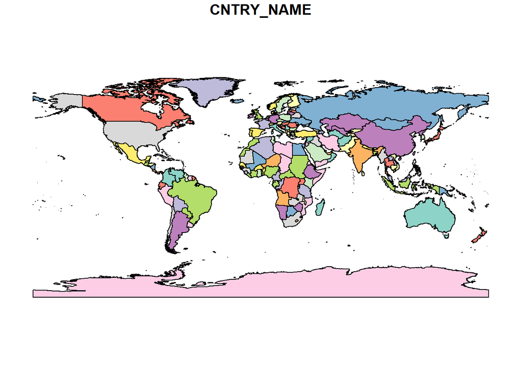

```r
#many plots, one per column of the data
# just plot the country names
plot(countries_sf["CNTRY_NAME"])
```

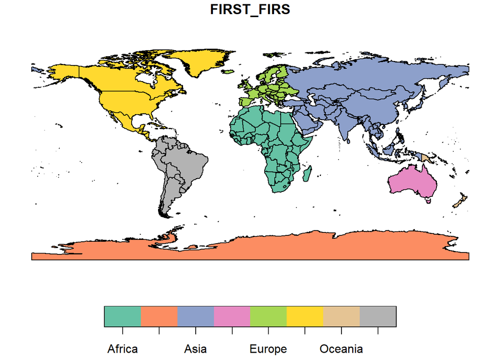

```r
plot(countries_sf[3])

# just plot the country names
plot(countries_sf["FIRST_FIRS"])
```

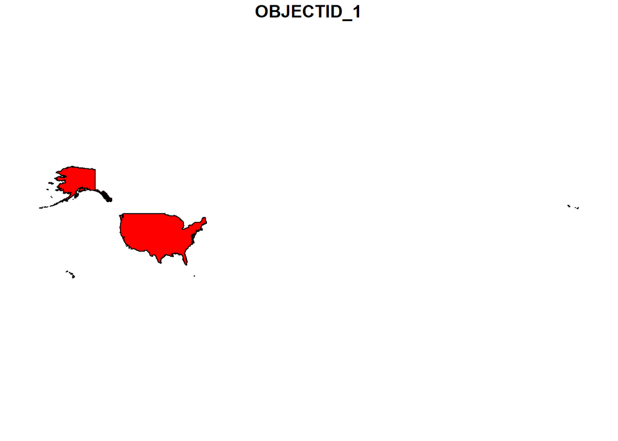

```r
# Let's plot the USA in red
USA_sf <- countries_sf[countries_sf$CNTRY_NAME == "USA",]
plot(USA_sf[1], col="red")
```

### Plotting a shapefile using the “ggplot2” package

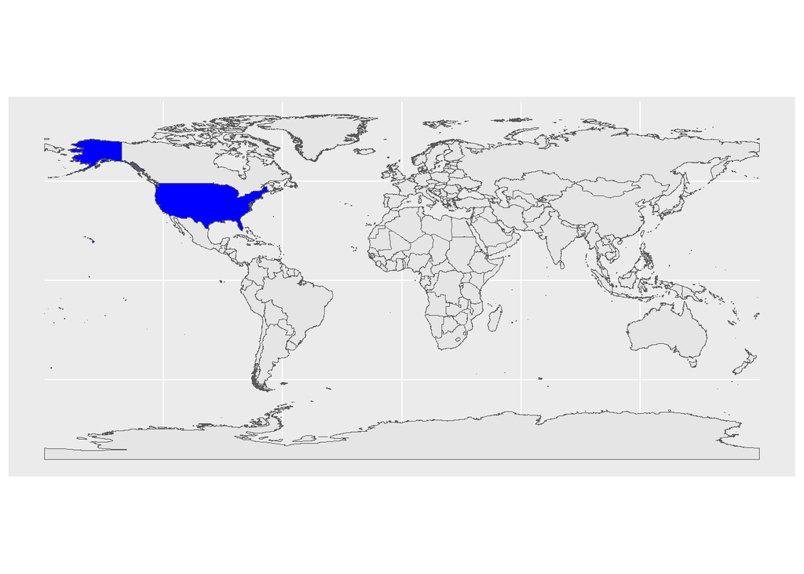

```r
library(ggplot2)
library(sf)
countries_sf <- st_read("H:/Geoprocessing_Shapefiles/Countries.shp")
m <- ggplot() + geom_sf(data=countries_sf)

# color in the United State blue
USA_sf <- countries_sf[countries_sf$CNTRY_NAME == "USA",]
m <- m + geom_sf(data=USA_sf, fill="blue")
m
```

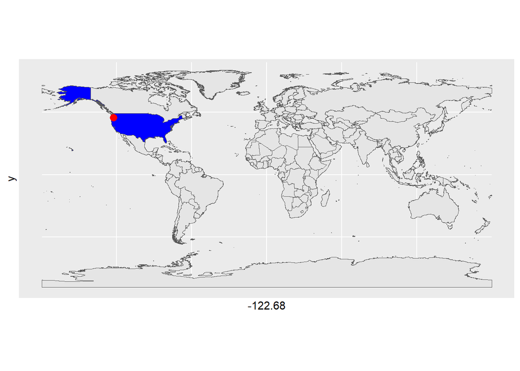

```r
# add a point for Portland
m <- m + geom_point(aes(x=-122.68, y=45.52), color="red", size=3)
m
```

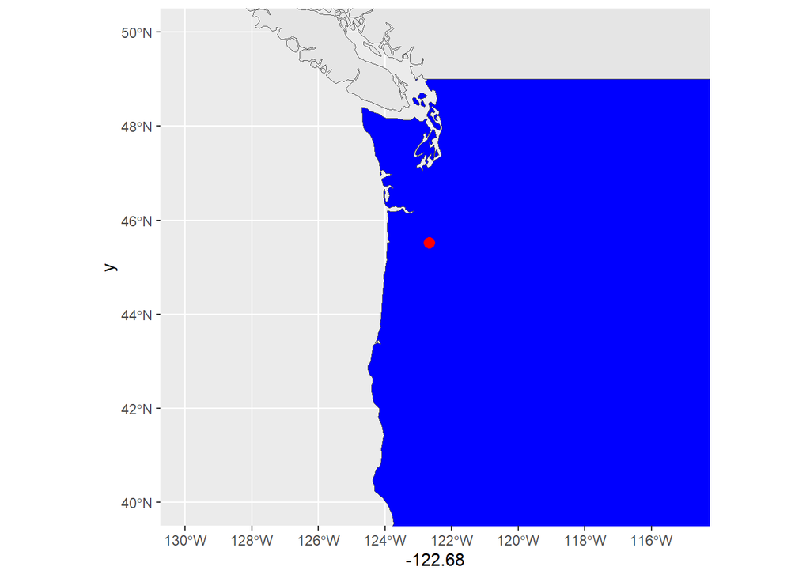

```r
# zoom in on the Pacific Northwest
m <- m + coord_sf(xlim=c(-130,-115), ylim=c(40,50))
m
```

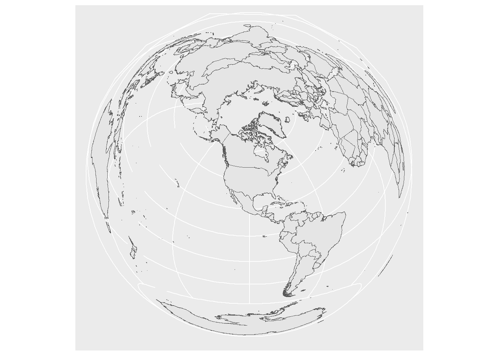

```r
# change the projection to laea
countries_sf2 <- st_transform(countries_sf,  "+proj=laea +lat_0=45 +lon_0=-100")
m <- ggplot() + geom_sf(data=countries_sf2)
m
```

Of course you could use specialized shapefiles at a much smaller scale if you wanted.

### Plot raster file with “terra” package

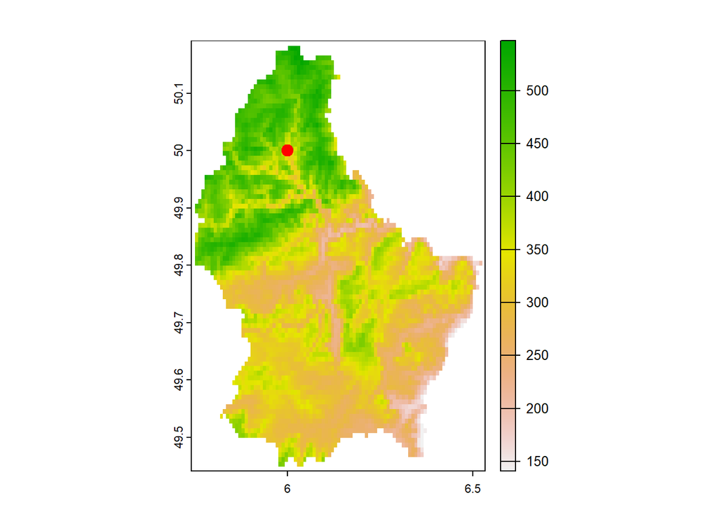

```r
library(terra)
r <- rast(system.file("ex/elev.tif", package="terra"))
plot(r)

# add a point at 50 N, 6 E
points(6, 50, col="red", pch=19, cex=1.5)
```

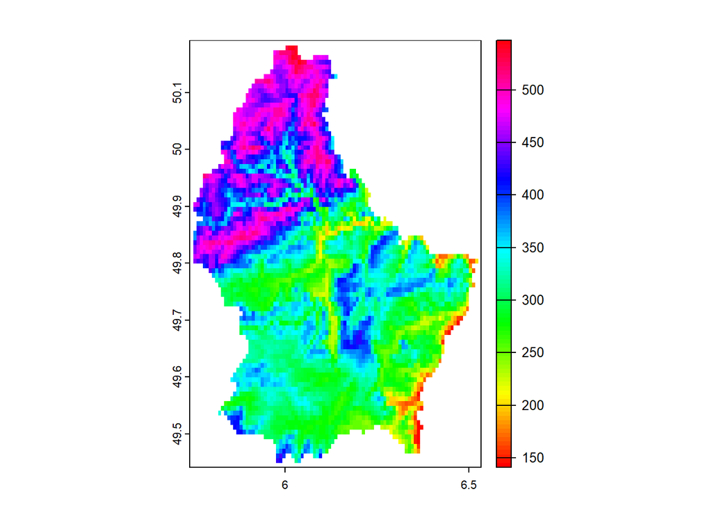

```r
# change the color scheme to raibow
plot(r, col=rainbow(100))
```

### Plot a dynamic map using the “leaflet” package

#### Note that the Leaflet map doesn’t seem to show up Teams, but it does show up if you save the file and open it in a browser.

```r
library(leaflet)
library(htmlwidgets)
center <- c(45, -124)
zoom <- 6
m <- leaflet() %>% setView(lng = center[2], lat = center[1], zoom = zoom) %>% addTiles()
# some 10 random points in Oregon
points <- data.frame(lat = runif(10, 42, 46), lon = runif(10, -124, -116))
# name the points
points$name <- paste0("Point ", 1:10)
# add the points to the map with a popup that shows the name of the point formatted as HTML
m <- m %>% addMarkers(data = points, lng = ~lon, lat = ~lat, popup = ~paste0("Name: ", name, "<br>Lat: ", lat, "<br>Lon: ", lon))
m
```

[interactive chart not shown]

```r
nc <- st_transform(st_read(system.file("shape/nc.shp", package="sf")), 2264)
```

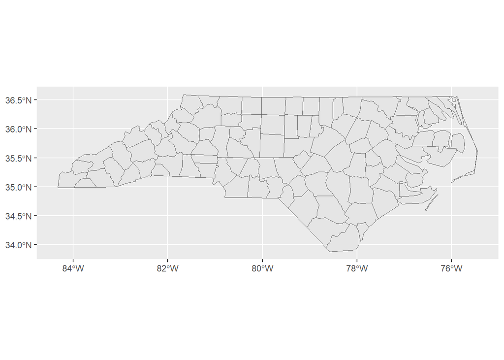

```r
# convert nc to geographic (lat/lon) coordinates
nc <- st_transform(nc, 4326)

nc_map <- ggplot() + geom_sf(data=nc)
nc_map
```

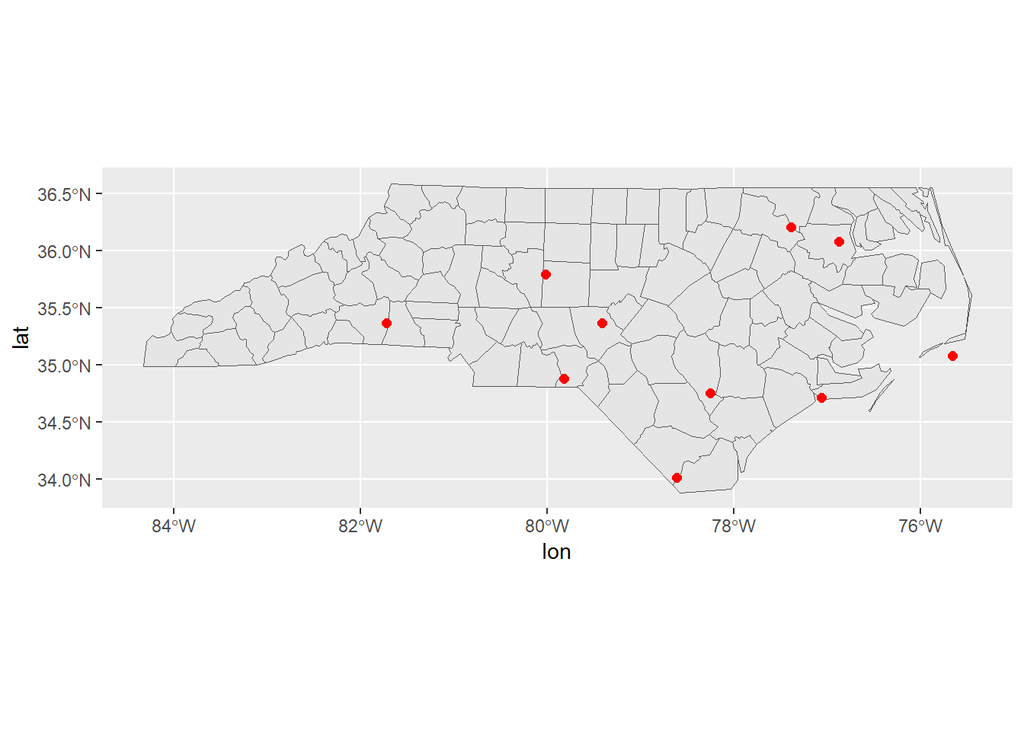

```r
# add 10 random points
points <- data.frame(lon = runif(10, st_bbox(nc)[1], st_bbox(nc)[3]), lat = runif(10, st_bbox(nc)[2], st_bbox(nc)[4]))
# add the points to the map
nc_map2 <- nc_map + geom_point(data=points, aes(x=lon, y=lat), color="red", size=2)
# show the map
nc_map2
```

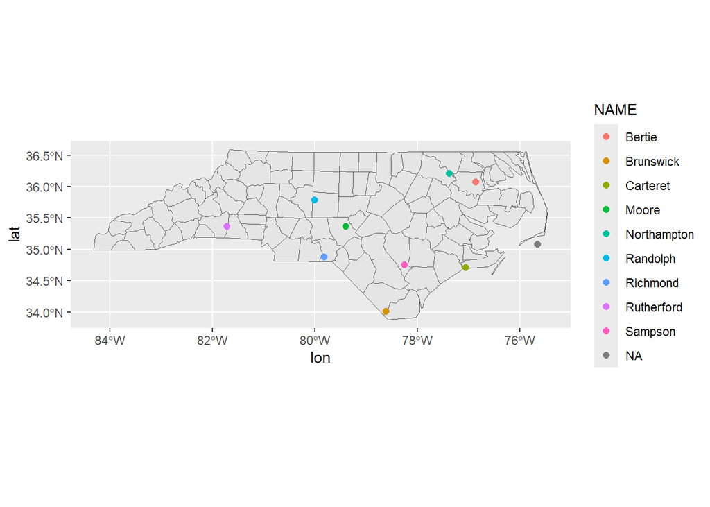

```r
# determine which county each point is in
points <- st_as_sf(points, coords=c("lon", "lat"), crs=st_crs(nc))
points <- st_join(points, nc)

# Extract coordinates from the geometry column
points_coords <- st_coordinates(points)
points$lon <- points_coords[, 1]
points$lat <- points_coords[, 2]

# add the points to the map, colored by county
nc_map3 <- nc_map + geom_point(data=points, aes(x=lon, y=lat, color=NAME), size=2)
nc_map3
```

```r
# format the point data into a table
points_table <- data.frame(points$lat, points$lon, points$NAME)
# replace NA values with "" in the county column
points_table$points.NAME[is.na(points_table$points.NAME)] <- ""
colnames(points_table) <- c("Latitude", "Longitude", "County")
knitr::kable(points_table)
```

| Latitude | Longitude | County |
| --- | --- | --- |
| 36.08000 | -76.87076 | Bertie |
| 36.20741 | -77.38469 | Northampton |
| 35.08016 | -75.65829 |  |
| 34.71352 | -77.06121 | Carteret |
| 35.79285 | -80.01400 | Randolph |
| 35.36875 | -79.40660 | Moore |
| 35.36470 | -81.72160 | Rutherford |
| 34.01403 | -78.61362 | Brunswick |
| 34.87946 | -79.82242 | Richmond |
| 34.75785 | -78.25554 | Sampson |